# Analyses des ouvrages du Morbihan (56), Bretagne

Apolline Carton

02/06/2024

# 1 Visualisation des ouvrages et de leur note d’expertise

## 1.1 Charger les données

### 1.1.1 installer les packages

```r
install.packages("sf")
install.packages("ggplot2")
install.packages("dplyr")
install.packages("stringr")
install.packages("tidyverse")
install.packages("rnaturalearth")
install.packages("grid")
install.packages("maps")
install.packages("gt")
```

### 1.1.2 charger les packages

```r
library(sf)
library(ggplot2)
library(dplyr)
library(stringr)
library(tidyverse)
library(rnaturalearth)
library(grid)
library(gt)
```

### 1.1.3 importer les données

```r
#Tableur excel contenant les informations sur les ouvrages et leur localisation :
library(readxl)
ouvrages_dpt_56 <- read_excel("données/dpt56/ouvrages_dpt_56.xlsx")
#View(ouvrages_dpt_56)

#Les différentes couches géographiques

  #les chemins d'accès depuis le disque dur de l'ordinateur (changer ici le chemin d'accès au besoin)

    #Zone d'Action Prioritaire Anguille (ZAP) (données de OFB)
ZAP <- "C:\\Users\\carto\\Desktop\\STAGE BGM\\scriptR\\données\\zap_anguille_bzh.gpkg"
    #Limites administratives du département du Morbihan (données de data.gouv.fr)
limite56 <- "C:\\Users\\carto\\Desktop\\STAGE BGM\\scriptR\\données\\dpt56\\limite56\\admin-departement.shp"
    #Plusieurs couches de cours d'eau complémentaires (données OFB)
courseau1 <- "C:\\Users\\carto\\Desktop\\STAGE BGM\\scriptR\\données\\cours d'eau\\tx_frac_brut_dpme_20230314.gpkg"
courseau2 <- "C:\\Users\\carto\\Desktop\\STAGE BGM\\scriptR\\données\\cours d'eau\\tx_frac_brut_rht_20230314.gpkg"
courseau3 <- "C:\\Users\\carto\\Desktop\\STAGE BGM\\scriptR\\données\\cours d'eau\\tx_frac_brut_syrah_20230314.gpkg"
    #Les cours d'eau inscrits à la liste 2 (données OFB)
liste2 <- "C:\\Users\\carto\\Desktop\\STAGE BGM\\scriptR\\données\\liste2\\Liste2_LB_2018_holobiotiques.gpkg"

  #importer les couches géographiques
ZAP <- st_read(ZAP)
liste2 <- st_read(liste2)
limite56 <- st_read(limite56)
courseau1 <- st_read(courseau1)
courseau2 <- st_read(courseau2)
courseau3 <- st_read(courseau3)
```

### 1.1.4 convertir les données de position GPS dans un format utilisable

Les données sur les ouvrages sont d’abord issues de la table attributaire sur le logiciel Qgis. En exportant la table attributaire sur le logiciel Excel, la colonne “wkt_geom” est automatiquement créée et ajoutée. Cette colonne contient les informations GPS permettant de localiser les points sur une carte. Le code suivant permet de convertir le format des données GPS pour pouvoir par la suite les utiliser.

```r
#conversion du foramt des données GPS
ouvrages_dpt_56 <- ouvrages_dpt_56 |>
  mutate (
    longitude = as.numeric(str_extract(wkt_geom, "(?<=Point \\()[0-9.-]+")),
    latitude = as.numeric(str_extract(wkt_geom, "(?<= )[0-9.-]+(?=\\))"))
  )
#head(ouvrages_dpt_56) #head() permet de visualiser l'objet pour voir si le code marche bien

#La ligne 32, ne contenant que des NA, est "créée" par le code précedant, on la supprime (sinon la suite du code est en erreur)
ouvrages_dpt_56 <- ouvrages_dpt_56 %>% filter(!is.na(wkt_geom))

#On trie l'objet ouvrages_dpt_35 pour retirer les lignes quand :
#- ouvrage_mer égal à "non", car l'analyse ne concerne que les ouvrages à la mer
#- visite = "en attente, car les données non pas encore été récoltées donc ces ouvrages ne sont pas pris en compte pour le rapport
#- note expertise = 0, car une note d'expertise de 0 signifie que l'ouvrage ne pose aucun problème et n'altère pas la structure du cours d'eau, et qu'il ne sera pas référencé dans la base ROE
ouvrages_dpt_56 <- ouvrages_dpt_56 |>
  filter(ouvrage_mer != "non") |>
  filter(visite !="en attente") |>
  filter(note_expertise !="0")

#choix du CRS (coordonate reference system) approprié (ici EPSG 2154)
#la fonction st_as_sf() permet convertir en objet sf
ouvrages_dpt_56 <- st_as_sf(ouvrages_dpt_56, coords = c("longitude", "latitude"), crs = 2154)
```

## 1.2 Réalisation de la carte

La carte suivante permet de visualiser les points dans l’espace, en fonction de la note d’expertise attribuée (donc de leur état de franchissabilité)

### 1.2.1 Code de la carte principale

```r
# Définir une échelle de couleurs pour la note de franchissement
  #La colonne note_expertise est une échelle discrète, pas continue, donc je dois dire à R les couleurs associées à chaque note

color_scale <- scale_color_manual(
  values = c(
    "0" = "paleturquoise",
    "1" = "palegreen2",
    "2" = "yellow1",
    "3" = "lightsalmon",
    "4" = "red1",
    "5" = "red4",
    "NA" = "grey1",
    "jugé conforme" = "palegreen2"
  )
)

# Faire un graphique (qui s'avère être la carte)
carte_note_56 <- ggplot() +
  geom_sf(data = limite56, fill = "gray82", color = "black") + #le contour du département
  geom_sf(data = ZAP, fill = "white", color = "white") + # ZAP anguille
  geom_sf(data = limite56, fill = NA, color = "black") +# pour remettre les limites terre-mer qui sont à moitiées cachées par ZAP
  geom_sf(data = courseau1, color = "lightblue") + #couches cours d'eau
  geom_sf(data = courseau2, color = "lightblue") +
  geom_sf(data = courseau3, color = "lightblue") +
  geom_sf(data = liste2, color = "red") + #couche cours d'eau en liste 2 (cours d'eau prioritaires)
  geom_sf(data = ouvrages_dpt_56,
          aes(color = as.factor(note_expertise)),
          shape = 16,
          size = 2, ) + # les points des ouvrages avec la couleur définie par la note d'expertise
  color_scale + # les couleurs sont dans l'objet color_scale
  theme_bw() +
  labs(
    size = "Note d'expertise",
    color = "Note d'expertise") +
  coord_sf(xlim = c(-3.58, -3.1), ylim = c(47.6, 47.80)) # Définir les limites de la carte
```

### 1.2.2 Code de la carte de situation

```r
#les données de la carte "france" proviennent du package "rnaturalearth"
france <- ne_countries(country = "france", returnclass = "sf")

#a carte de la France avec un encadré de la zone d'étude (=carte principale)
carte_france_56 <- ggplot(data = france) +
  geom_sf(fill = "gray82", color = "black") + #choix des couleur de fond et de contour de la France
  theme_void() +  # Supprimer les axes et les titres
  geom_rect(aes(xmin = -3.58, xmax = -3.1, ymin = 47.6, ymax = 47.80), fill = NA, color = "red", size = 1) + #encadré de la zone d'étude --> les limites sont les mêmes que celle de la carte principale
  xlim(-5, 10) +  # Ajuster les limites de la carte pour mieux cadrer sur la France
  ylim(40, 52) +
  theme(panel.background = element_rect(fill = "white", color = "black"))
```

### 1.2.3 Insérer la carte de localisation “carte_france_56” sur la carte principale “carte_note_56”

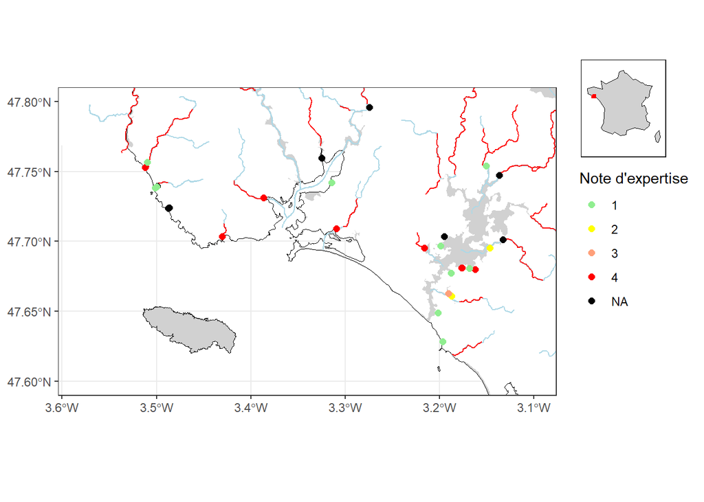

```r
#Grob permet de fusionner les graphiques
carte_france_56_grob <- ggplotGrob(carte_france_56)

# Ajouter la carte de localisation à la carte principale
carte_note_56_grob <- carte_note_56 +
  annotation_custom(
    grob = carte_france_56_grob,
    xmin = -2.96, xmax = -3.05, #choix de la position de la carte de localisation
    ymin = 47.83, ymax = 47.76
  )

#Visualiser la carte
carte_note_56_grob
```

### 1.2.4 Exporter la carte au format PNG sur le disque dur de l’ordinateur

```r
# Enregistrer la carte au format PNG
ggsave("C:\\Users\\carto\\Desktop\\STAGE BGM\\rapport\\figures\\Prio 56\\carte_prio_56_0206_LUI.png", plot = carte_prio_56_grob, dpi = 300)
```

# 2 Plan d’action : prioriser les ouvrages selon des critères de priorisation

## 2.1 Prioriser selon les critères Liste 2 et Note d’expertise

- Liste 2 : l’ouvrage est ou non sur un cours d’eau prioritaire
- Note d’expertise : l’ouvrage est un obstacle à la migration

### 2.1.1 Les ouvrages sur un cours d’eau en liste 2

Pour savoir si un ouvrage est en liste 2, on réalise une intersection : est-ce-que le point croise une ligne de cours d’eau en liste 2 ? Pour cela, il faut d’abord créer un tampon autour du point. la taille du tampon a été définie visuellement avec mapview:mapview, afin d’avoir un tampon assez large mais pas trop.

```r
#définir la taille du tampon ; le tampon est nécessaire pour faire l'intersection ; il faut bien choisir la taille
taille_tampon <- 100
ouvrages_56_tampon <- st_buffer(ouvrages_dpt_56, dist = taille_tampon)

# code pour voir l'objet de manière intéractive --> permet de vérifier que le tampon a une taille cohérente
#mapview::mapview(ouvrages_tampon)

# l'objet intersection permet de savoir si les points sont sur un cours d'eau en liste 2
intersection56 <- st_intersects(ouvrages_56_tampon, liste2)
#View(intersection56)

#l'objet liste2_56 continent l'information de l'objet "intersection56" dans un format data.frame utilisable
liste2_56<- intersection56 %>%
  map(.f = length) %>%
  as.data.frame() %>%  # il faut le remettre en data frame
  t() %>%  # on transporse le format ligne en colonne
  as.data.frame() # il faut le remettre en format data frame

# on crée le tableau priorite_liste2_56, dans lequel on pourra créer les colonnes souhaitées pour prioriser les ouvrages
priorite_liste2_56 <- ouvrages_dpt_56 %>%
  cbind(liste2_56) %>% # on "colle" l'objet liste2_56
  rename(liste2 = V1) %>% # on renote la colonne (la colonne s'appelle V1, on renomme en liste2)
  mutate(liste2 = (liste2 > 0), # la variable liste2 va contenir des "TRUE" ou des "FALSE" -> TRUE = ouvrage sur liste2 ; FALSE = ouvrage par sur liste 2
         urgence = case_when(
           liste2 & note_expertise %in% c("4", "5") ~ "prioritaire",
           liste2 & note_expertise %in% c("3", "2") ~ "moyennement prioritaire",
           liste2 & note_expertise == "1" ~"non prioritaire",
           !liste2 & note_expertise %in% c("4", "5") ~ "moyennement prioritaire",
           !liste2 & note_expertise %in% c("3", "2") ~ "peu prioritaire",
           TRUE ~ "non prioritaire"
         )) # chaine pour énumérer les critères
# on créer la variable urgence grâce à la fonction mutate
#si ouvrage en liste 2 ET avec une note de 4 ou 5, alors il est "prioritaire"
#si ouvrage en liste 2 ET avec une note de 2 ou 3 / si l'ouvrage n'est pas en liste 2 mais avec une note de 4 ou 5 alors il est "moyennement prioritaire"
#si l'ouvrage n'est pas en liste 2 et avec une note de 2 ou 3, alors il est "peu prioritaire"
#si l'ouvrage ne répond à aucune des conditions précédentes, il est "non prioritaire"

#View(priorite_liste2_56)
```

### 2.1.2 Priorité des ouvrages en fonction de leur position sur le cours d’eau

Les premiers ouvrages à la mer sont prioritaire sur les ouvrages qui suivent en amont. Un second ouvrage à la mer va “gagner” en priorité si le premier ouvrage à la mer ne pose pas de problème à la migration

```r
#Appliquer des conditions supplémentaires concernant l'ordre des ouvrages
priorite_ordre_ouvrage_56 <- priorite_liste2_56 %>%
  group_by(nom_ouvrage_1) %>% #la variable "nom_ouvrage_1" contient l'information des ouvrages sur le même cours d'eau..
  mutate(urgence = case_when(
    # 1e condition : dégrader en "non prioritaire" un second ouvrage à la mer quand le premier est "prioritaire" ou "moyennement prioritaire"
    ordre_mer == 2 &
      urgence %in% c("prioritaire", "moyennement prioritaire") &
      any(urgence %in% c("prioritaire", "moyennement prioritaire") & nom_ouvrage_1 == first(nom_ouvrage_1)) ~ "non prioritaire",

    # 2e condition : reclassé en "moyennement prioritaire" un second ouvrage à la mer quand le premier est "non prioritaire"
    ordre_mer == 2 &
      urgence == "peu prioritaire" &
      any(urgence == "non prioritaire" & nom_ouvrage_1 == first(nom_ouvrage_1)) ~ "moyennement prioritaire",

    # Si un ouvrage ne remplit pas ces conditions, rien ne change.
    TRUE ~ urgence
  )) %>%
  ungroup() #on a groupé les 1e et 2nd ouvrages à la mer du même cours d'eau, on les dégroupe

View(priorite_ordre_ouvrage_56)
```

## 2.2 Visualiser les ouvrages prioritaires sur une carte

### 2.2.1 La carte principale (le code est similaire au précédant code de carte)

```r
color_scale_prio_56 <- scale_color_manual(
  values = c(
    "prioritaire" = "red4",
    "moyennement prioritaire" = "lightsalmon",
    "peu prioritaire" = "yellow1",
    "non prioritaire" = "palegreen2"
  ),
  breaks = c("prioritaire", "moyennement prioritaire", "peu prioritaire", "non prioritaire") # choisir l'ordre des éléments de la légende
)

carte_prio_56 <- ggplot() +
  geom_sf(data = limite56, fill = "gray82", color = "black") + #le contour du dpt
  geom_sf(data = ZAP, fill = "white", color = "white") + # ZAp anguille
  geom_sf(data = limite56, fill = NA, color = "black") +# pour remettre les limites terre-mer qui sont à mmoitiées cachées par ZAP
  geom_sf(data = courseau1, color = "lightblue") + #couches cours d'eau
  geom_sf(data = courseau2, color = "lightblue") +
  geom_sf(data = courseau3, color = "lightblue") +
  geom_sf(data = liste2, color = "red") + #couche cours d'eau en liste 2 (prio)
  geom_sf(data = priorite_ordre_ouvrage_56,
          aes(color = as.factor(urgence)),
          shape = 16,
          size = 2, ) + # les pts des ouvrages avec variation selon note expertise
  color_scale_prio_56 + # dire quelle couleur pour quelle note
#  size_scale + # dire quelle taille pour quelle note
 # geom_sf(data = ouvrages_dpt35 |> filter(is.na(note_expertise)), size = 1.5, color = "grey") + # Certains ouvrages ont NA pour note !!!
  theme_bw() +
  labs(
    size = "Priorité d'action",
    color = "Priorité d'action") +
  coord_sf(xlim = c(-3.58, -3.1), ylim = c(47.6, 47.80)) + # Définir les limites des latitude
  geom_sf_label(data = priorite_ordre_ouvrage_56 %>% filter(urgence == "prioritaire"),
                aes(label = nom_principal),
                size = 3,
                color = "red4",
                fill = "white", # Fond blanc derrière le texte
                label.padding = unit(0.15, "lines"), # Padding pour le fond du label
                nudge_y = 0.01) # Ordre des étiquettes dans la légende
```

### 2.2.2 Carte finale

On ajoute la carte de localisation de la France (la même que pour la carte précédente)

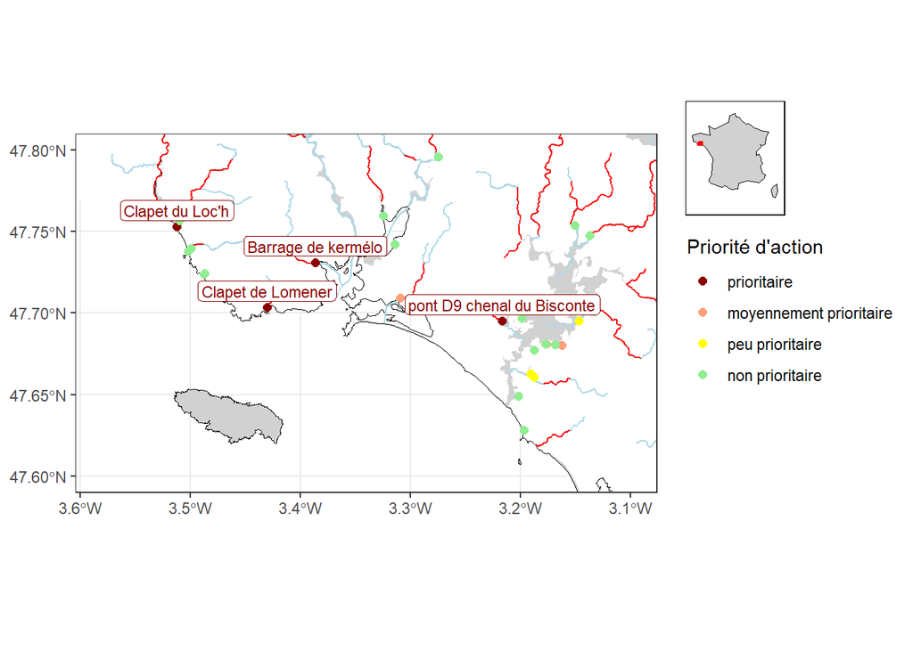

```r
# Ajouter la sous-carte à la carte principale
carte_prio_56_grob <- carte_prio_56 +
  annotation_custom(
    grob = carte_france_56_grob,
    xmin = -2.96, xmax = -3.05,
    ymin = 47.83, ymax = 47.76
  ) +
  theme(
    axis.title = element_blank(), # Supprimer les titres des axes
  )

#afficher la carte
carte_prio_56_grob
```

## 2.3 Tableau des ouvrages à la mer et de leur priorité d’action

```r
tableau_priorite_56 <- priorite_ordre_ouvrage_56 |>
  st_drop_geometry() |> # Supprimer la colonne 'geometry'
  select(reference, nom_principal, urgence) |>
  arrange(factor(urgence, levels = c("prioritaire", "moyennement prioritaire", "peu prioritaire", "pas prioritaire")))
#View(tableau_priorite_56)

Tableau_priorite_56 <- tableau_priorite_56 %>%
  gt() %>%
  tab_header(
    title = md("**Ouvrages Prioritaires**"),
    subtitle = "Liste des ouvrages avec priorité premier et second"
  ) %>%
  cols_label(
    reference = "Référence",
    nom_principal = "Nom Principal",
    urgence = "Ordre de Priorité"
  ) %>%
  tab_style(
    style = cell_text(weight = "bold"),
    locations = cells_title(groups = "title")
  ) %>%
  tab_style(
    style = cell_text(style = "italic"),
    locations = cells_title(groups = "subtitle")
  ) %>%
  tab_style(
    style = cell_text(align = "center", weight = "bold"),
    locations = cells_column_labels(everything())
  ) %>%
  tab_style(
    style = cell_text(align = "center"),
    locations = cells_body(columns = everything())
  ) %>%
  tab_options(
    table.border.top.color = "black",
    table.border.bottom.color = "black",
    table.border.left.color = "black",
    table.border.right.color = "black",
    heading.align = "left"
  )

Tableau_priorite_56
```

**Ouvrages Prioritaires**

Liste des ouvrages avec priorité premier et second

| Référence | Nom Principal | Ordre de Priorité |
| --- | --- | --- |
| oui | Clapet de Lomener | prioritaire |
| oui | Clapet du Loc'h | prioritaire |
| oui | Barrage de kermélo | prioritaire |
| non | pont D9 chenal du Bisconte | prioritaire |
| oui | Bassin de Riantec | moyennement prioritaire |
| non | route de Ninezur | moyennement prioritaire |
| non | rue du Lannion | moyennement prioritaire |
| oui | Moulin du Sac'h | peu prioritaire |
| non | barrage Pointe de Keiro | peu prioritaire |
| non | pont du Moulin du Bignac | peu prioritaire |
| oui | Moulin de la Demi-Ville | non prioritaire |
| oui | Barrage du Moulin de Berringue | non prioritaire |
| oui | Etang du Loc'h | non prioritaire |
| oui | Moulin du Plessis | non prioritaire |
| oui | Seuil de l'Etang de Lannenec | non prioritaire |
| oui | Etang de Saint-Jean | non prioritaire |
| oui | Moulin du Palais | non prioritaire |
| non | rue de guidel | non prioritaire |
| non | route de la plage de Pen er Malo | non prioritaire |
| non | plage des Kaolins | non prioritaire |
| non | boulevard de l'atlantique | non prioritaire |
| non | route de Sterbouest | non prioritaire |
| non | route de Port-Louis | non prioritaire |
| non | barrage Mané-Garuetch | non prioritaire |
| non | petite route de la rue des Pêcheurs | non prioritaire |
| non | rue du moulin des Oies | non prioritaire |
| non | route de Pont er Laul | non prioritaire |
| non | pont Le Ré | non prioritaire |
| non | plage naturiste d'Erdeven Kerminihy | non prioritaire |